# Introduction

For my project, I dived into HappyDB, a huge collection of 100,000 stories about happy moments from people around the world. My curiosity led me to ask three questions: What are the common happy moments people talk about? Do these moments change as people get older or their life situations change? And how do cultural backgrounds influence the way people experience and talk about happiness? My goal was to sift through these stories to understand the bigger picture of happiness. By exploring these questions, I aimed to piece together a simple yet detailed story of what happiness looks like across different ages, places, and lifestyles. This project was about making sense of these many moments of joy, hoping to find patterns that show us more about what brings happiness to people's lives.

# Data Preprocessing

```python
import pandas as pd


df_cleaned_hm = pd.read_csv("cleaned_hm.csv")
df_demographic = pd.read_csv("demographic.csv")

df_cleaned_hm.head(), df_demographic.head()
```

```
(    hmid   wid reflection_period  \
 0  27673  2053               24h
 1  27674     2               24h
 2  27675  1936               24h
 3  27676   206               24h
 4  27677  6227               24h

                                          original_hm  \
 0  I went on a successful date with someone I fel...
 1  I was happy when my son got 90% marks in his e...
 2       I went to the gym this morning and did yoga.
 3  We had a serious talk with some friends of our...
 4  I went with grandchildren to butterfly display...

                                           cleaned_hm  modified  num_sentence  \
```

[output cut: 18 more lines]

Merge the two datasets, so we can analysis the text with more demographic insights.

```python
## left merge
merged_df = pd.merge(df_cleaned_hm, df_demographic, on='wid', how='left')

merged_df.head()
```

|  | hmid | wid | reflection_period | original_hm | cleaned_hm | modified | num_sentence | ground_truth_category | predicted_category | age | country | gender | marital | parenthood |
| --- | --- | --- | --- | --- | --- | --- | --- | --- | --- | --- | --- | --- | --- | --- |
| 0 | 27673 | 2053 | 24h | I went on a successful date with someone I fel... | I went on a successful date with someone I fel... | True | 1 | NaN | affection | 35 | USA | m | single | n |
| 1 | 27674 | 2 | 24h | I was happy when my son got 90% marks in his e... | I was happy when my son got 90% marks in his e... | True | 1 | NaN | affection | 29.0 | IND | m | married | y |
| 2 | 27675 | 1936 | 24h | I went to the gym this morning and did yoga. | I went to the gym this morning and did yoga. | True | 1 | NaN | exercise | 30 | USA | f | married | y |
| 3 | 27676 | 206 | 24h | We had a serious talk with some friends of our... | We had a serious talk with some friends of our... | True | 2 | bonding | bonding | 28 | DNK | f | married | n |
| 4 | 27677 | 6227 | 24h | I went with grandchildren to butterfly display... | I went with grandchildren to butterfly display... | True | 1 | NaN | affection | 55 | USA | f | divorced | y |

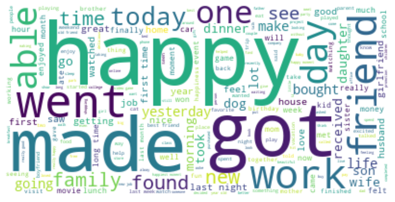

```python
from wordcloud import WordCloud
import matplotlib.pyplot as plt
import seaborn as sns
text = " ".join(review for review in merged_df.cleaned_hm.dropna())
wordcloud = WordCloud(background_color="white").generate(text)

plt.figure(figsize=(10, 5))
plt.imshow(wordcloud, interpolation='bilinear')
plt.axis("off")
plt.show()
```

The frequent appearance of words like "happy," "made," and "got" in the word cloud from the happy moments dataset reveals interesting insights:

1 happy:This word's prominence is expected in a dataset about happy moments. It shows that people often explicitly state their happiness, directly acknowledging the feeling.

2 made: Its frequent use suggests that these happy moments are often seen as results of specific actions or occurrences. It points to an understanding that happiness often comes from something being done or created, either by oneself or others.

3 got: The regular appearance of this word indicates that acquiring or receiving something often leads to happiness. This could be anything from physical items to achievements or good news.

In summary, these words highlight that happiness is openly expressed, commonly linked to specific actions or events, and often involves gaining something positive. This gives us a glimpse into what people consider as sources of their happiness.

# Question one: What are the common themes or categories of happy moments, and how do they differ across different demographic groups?(LDA)

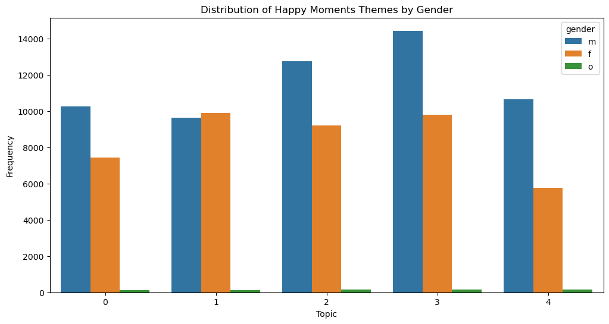

```
{0: ['day',
  'happy',
  'work',
  'got',
  'wife',
  'life',
  'home',
  'night',
  'moment',
  'today'],
 1: ['happy',
  'time',
  'daughter',
  'son',
  'school',
  'got',
  'event',
  'past',
  'year',
  'months'],
 2: ['went',
  'friend',
  'friends',
  'family',
  'time',
  'dinner',
  'happy',
  'birthday',
  'good',
  'long'],
 3: ['new',
  'got',
  'work',
  'happy',
  'job',
  'bought',
  'dog',
  'received',
  'car',
  'really'],
 4: ['got',
  'game',
  'favorite',
  'won',
  'watched',
  'happy',
  'able',
  'finally',
  'video',
  'team']}
```

```python
data = merged_df['cleaned_hm'].dropna()

# document-term matrix
count_vect = CountVectorizer(max_df=0.95, min_df=2, stop_words='english')
dtm = count_vect.fit_transform(data)

# Fitting LDA
n_topics = 5  # Number of topics
lda = LatentDirichletAllocation(n_components=n_topics, random_state=0)
lda.fit(dtm)

# Displaying the top words in each topic
def display_topics(model, feature_names, no_top_words):
    topics = {}
    for topic_idx, topic in enumerate(model.components_):
        top_features_ind = topic.argsort()[:-no_top_words - 1:-1]
        top_features = [feature_names[i] for i in top_features_ind]
        topics[topic_idx] = top_features
    return topics

no_top_words = 10
topics = display_topics(lda, count_vect.get_feature_names_out(), no_top_words)

# Assigning topics to each document
topic_results = lda.transform(dtm)
merged_df['Topic'] = topic_results.argmax(axis=1)

# Visualizing the distribution of topics across different demographic groups
def plot_topic_distribution(df, demographic_variable, title):
    plt.figure(figsize=(12, 6))
    sns.countplot(x='Topic', hue=demographic_variable, data=df)
    plt.title(title)
    plt.xlabel('Topic')
    plt.ylabel('Frequency')
    plt.show()

plot_topic_distribution(merged_df, 'gender', 'Distribution of Happy Moments Themes by Gender')

topics
```

topic modeling analysis of the "happy moments" dataset utilizing Latent Dirichlet Allocation (LDA) has yielded five distinct themes that provide insights into the various facets that contribute to people's happiness. Each theme is enriched with specific keywords:

Topic 0(Family and everyday life):This theme is rooted in the routine and familial aspects of life. Keywords like 'day,' 'work,' 'wife,' and 'home' reflect the significance of daily experiences and close family relationships in contributing to happiness. The words 'night' and 'moment' may denote the appreciation of small, daily occurrences and intimate family time, underlining the joy found in the day-to-day and the comfort of domestic life.

Topic 1(Family growth and Time):This theme revolves around the growth and evolution of family, as denoted by words like 'daughter,' 'son,' 'school,' and 'year.' It suggests that happiness is deeply tied to family dynamics and the progress of time, with 'event,' 'past,' and 'months' pointing to the celebration of life's events and the passing of time.

Topic 2(social life):This theme captures moments related to 'friend,' 'friends,' 'family,' and 'dinner.' It indicates that social gatherings, including birthdays and meals shared with loved ones, are substantial sources of joy. The presence of 'good' and 'long' may indicate the quality and duration of these relationships as integral to happiness.

Topic 3(Work and new acquisitions): This theme suggests that personal achievements and new possessions, such as 'job,' 'new,' 'bought,' 'dog,' and 'car,' play a pivotal role in happiness. The word 'received' hints at the pleasure derived from both receiving and obtaining new items or reaching milestones at work, reflecting the impact of material and professional satisfaction on overall well-being.

Topic 4(Leisure and Entertainment): Reflecting the joy found in hobbies and entertainment, keywords like 'game,' 'watched,' 'favorite,' and 'team' depict happiness associated with personal interests and leisure activities. The words 'won' and 'finally' may express the exhilaration of achievements in personal hobbies, while 'able' underscores the ability to engage in and enjoy these pursuits.

From this analysis, we can draw several inferences about how happiness themes differ by gender. Men seem to report more happiness associated with social and leisure activities, as well as work-related achievements and new acquisitions. In contrast, the representation of these themes among women, while significant, is not as pronounced in this dataset.

# Question two:How do emotions and sentiments expressed in happy moments evolve with age and over different life stages?(Sentiment analysis)

```python
pip install textblob
```

```
     -------------------------------------- 636.8/636.8 kB 6.7 MB/s eta 0:00:00
```

[output not shown]

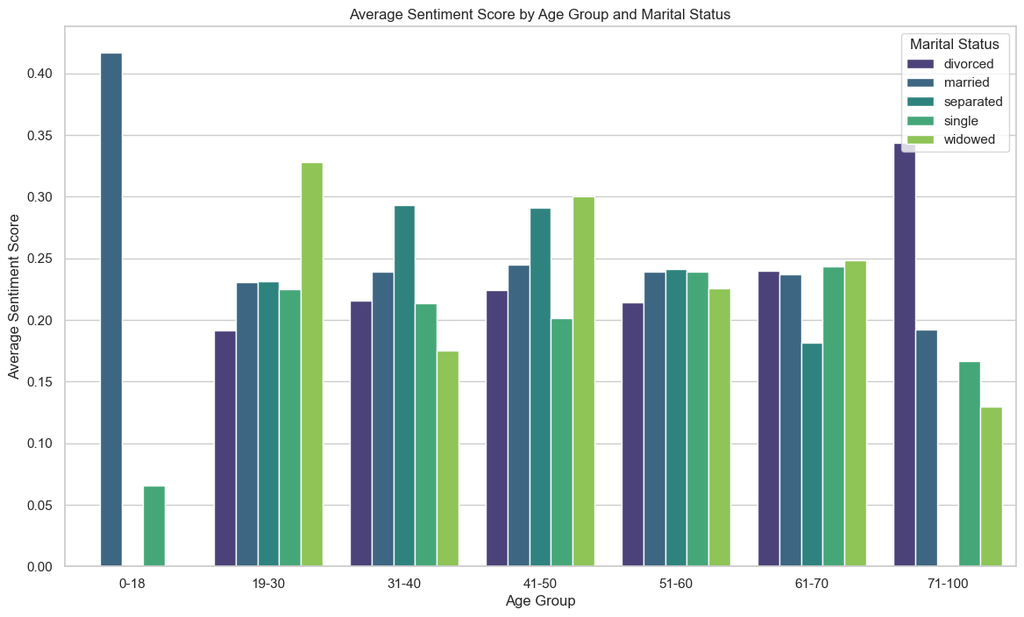

```python
from textblob import TextBlob

# Sentiment analysis
def calculate_sentiment(text):
    return TextBlob(text).sentiment.polarity

# Applying sentiment analysis
merged_df['sentiment'] = merged_df['cleaned_hm'].apply(calculate_sentiment)

# Clean 'age' column and categorize data by age groups
merged_df['age'] = pd.to_numeric(merged_df['age'], errors='coerce')
age_bins = [0, 18, 30, 40, 50, 60, 70, 100]
age_labels = ['0-18', '19-30', '31-40', '41-50', '51-60', '61-70', '71-100']
merged_df['age_group'] = pd.cut(merged_df['age'], bins=age_bins, labels=age_labels, right=False)

# calculate mean sentiment
age_life_stage_sentiment = merged_df.groupby(['age_group', 'marital']).agg({'sentiment': 'mean'}).reset_index()

# Visualization
sns.set(style="whitegrid")
plt.figure(figsize=(14, 8))
sns.barplot(x='age_group', y='sentiment', hue='marital', data=age_life_stage_sentiment, palette='viridis')
plt.title('Average Sentiment Score by Age Group and Marital Status')
plt.xlabel('Age Group')
plt.ylabel('Average Sentiment Score')
plt.legend(title='Marital Status', loc='upper right')
plt.show()
```

The bar graph illustrates how feelings and emotions have changed over time during happy moments for different age groups and marital circumstances. It provides insight into how people show their satisfaction differently depending on their age and marital status.

The sentiment scores of married people in the '19-30' age group are somewhat higher than those of unmarried people, indicating that early adulthood marriage is linked to pleasant and good feelings. Those who are widowed, separated, or divorced have notably different sentiment scores, which may be a reflection of the complicated feelings that come with these situations at a very young age.

The sentiment scores of people in the '31-40', '41-50', and '51-60' age groups show greater disparities depending on their marital status. Married people tend to score higher than single people, suggesting a possible link between marriage and positive emotions in middle age.

# Question Three: Are there observable differences in the themes of happiness among different countries or cultures represented in the dataset?(Clustering & Comparative analysis)

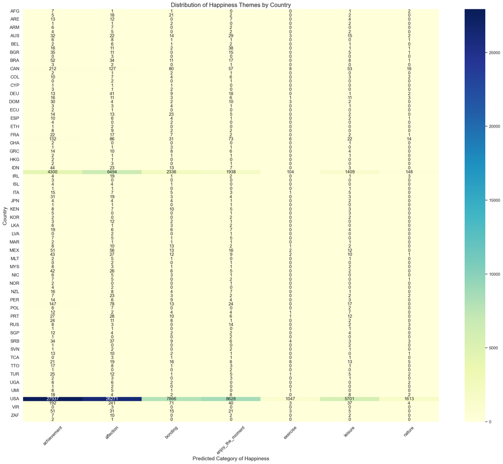

```python
merged_df =merged_df.dropna(subset=['country', 'predicted_category'])

# Grouping by country and predicted_category and counting occurrences
happiness_themes_by_country = merged_df.groupby(['country', 'predicted_category']).size().reset_index(name='count')

# Pivot the data for better visualization
pivot_table = happiness_themes_by_country.pivot(index='country', columns='predicted_category', values='count').fillna(0)

# Plotting
plt.figure(figsize=(25, 20))
sns.heatmap(pivot_table, annot=True, fmt=".0f", cmap="YlGnBu", annot_kws={"size": 12})
plt.title('Distribution of Happiness Themes by Country', fontsize=16)
plt.ylabel('Country', fontsize=14)
plt.xlabel('Predicted Category of Happiness', fontsize=14)
plt.xticks(rotation=45, fontsize=12)
plt.yticks(rotation=0, fontsize=12)
plt.show()
```

# Conclusion

The heatmap verifies that themes related to happiness vary among nations, indicating the impact of cultural and socioeconomic elements on individuals' perceptions of their joyful times. While the USA and other nations exhibit a wide range of pleasure themes, other nations may exhibit clear preferences for particular themes that reflect particular cultural values.

In conclusion, happiness is a complicated feeling that is influenced by a wide range of elements, such as family, social relationships, individual accomplishments, and cultural setting. Despite the fact that some themes are universal, there are significant differences in how they are expressed and interpreted depending on factors such as gender, age, marital status, and cultural background.